# Predicting Successful Kickstarter Project

Group-26

## Loading the data

The data-sets are loaded and external data-set containing both the user-country and user-state was added to a larger data-set.

```r
knitr::opts_chunk$set(echo = TRUE)
#load data files
train_x <- read_csv("ks_training_X.csv") %>%
  mutate(original_TR = 1)
train_y <- read_csv("ks_training_y.csv")
test_x <- read_csv("ks_test_X.csv") %>%
  mutate(original_TR = 0)
#rbind binds rows
total <- rbind(train_x, test_x)

#join the training y to the training x file
#also turn two of the target variables into factors
total <- total %>%
  left_join(train_y, by = "id")

#loading external data-set to extract creator country and state
load("38050-0003-Data.rda")

da38050.0003 <- da38050.0003 %>%
  distinct(PID, .keep_all = TRUE)

#combining to create a new dataset
total <- total %>%
  left_join(da38050.0003, by = c(id = "PID"))
```

```r
summary(total)
```

```
##        id              creator_id            name           creator_name
##  Min.   :5.971e+03   Min.   :3.000e+00   Length:108728      Length:108728
##  1st Qu.:5.372e+08   1st Qu.:5.352e+08   Class :character   Class :character
##  Median :1.076e+09   Median :1.072e+09   Mode  :character   Mode  :character
##  Mean   :1.076e+09   Mean   :1.072e+09
##  3rd Qu.:1.613e+09   3rd Qu.:1.608e+09
##  Max.   :2.147e+09   Max.   :2.147e+09
##
##     blurb                goal           deadline            created_at
##  Length:108728      Min.   :   100   Min.   :2009-05-15   Min.   :2009-04-21
##  Class :character   1st Qu.:  2000   1st Qu.:2012-04-01   1st Qu.:2012-01-31
##  Mode  :character   Median :  5000   Median :2013-03-29   Median :2013-01-01
##                     Mean   : 13788   Mean   :2013-02-15   Mean   :2012-12-04
##                     3rd Qu.: 14000   3rd Qu.:2014-03-26   3rd Qu.:2013-12-27
##                     Max.   :250000   Max.   :2014-12-02   Max.   :2014-11-21
##
##   launched_at         location_slug      location_type         region
##  Min.   :2009-04-21   Length:108728      Length:108728      Length:108728
##  1st Qu.:2012-02-24   Class :character   Class :character   Class :character
##  Median :2013-02-25   Mode  :character   Mode  :character   Mode  :character
##  Mean   :2013-01-11
##  3rd Qu.:2014-02-21
##  Max.   :2014-11-26
##
##  category_parent    category_name      numfaces_project  numfaces_creator
##  Length:108728      Length:108728      Min.   : 0.0000   Min.   :0.0000
##  Class :character   Class :character   1st Qu.: 0.0000   1st Qu.:0.0000
##  Mode  :character   Mode  :character   Median : 0.0000   Median :0.0000
##                                        Mean   : 0.2905   Mean   :0.5091
##                                        3rd Qu.: 0.0000   3rd Qu.:1.0000
##                                        Max.   :25.0000   Max.   :9.0000
##
##   male_project     male_creator    female_project    female_creator
##  Min.   : 0.000   Min.   :0.0000   Min.   : 0.0000   Min.   :0.0000
##  1st Qu.: 0.000   1st Qu.:0.0000   1st Qu.: 0.0000   1st Qu.:0.0000
##  Median : 0.000   Median :0.0000   Median : 0.0000   Median :0.0000
##  Mean   : 0.155   Mean   :0.3188   Mean   : 0.1206   Mean   :0.1882
##  3rd Qu.: 0.000   3rd Qu.:1.0000   3rd Qu.: 0.0000   3rd Qu.:0.0000
##  Max.   :25.000   Max.   :8.0000   Max.   :21.0000   Max.   :8.0000
##
```

[output cut: 81 more lines]

```
##  Min.   :    0.00   Min.   :      15   CA                            :24639
##  1st Qu.:    4.00   1st Qu.:  382404   NY                            : 9862
##  Median :   19.00   Median : 1144882                                 : 9818
##  Mean   :   97.52   Mean   : 2357771   TX                            : 4716
##  3rd Qu.:   64.00   3rd Qu.: 3618508   FL                            : 3587
##  Max.   :68929.00   Max.   :11093864   (Other)                       :45773
##  NA's   :11308      NA's   :10333      NA's                          :10333
##  USER_LOCATION_COUNTRY     COUNT       TOTAL_AMOUNT_IN_USD
##  US     :84195         1      :17463   $25       : 2787
##         : 9814         2      : 8439   $10       : 2550
##  GB     : 1435         3      : 5468   $1        : 2513
##  CA     :  613         4      : 4374   $5        : 2325
##  AU     :  352         5      : 3641   $50       : 2221
##  (Other): 1986         (Other):59010   (Other)   :85999
##  NA's   :10333         NA's   :10333   NA's      :10333
```

## Cleaning and feature engineering

Cleaned the reward amounts to get max,min and num_rewards

```r
knitr::opts_chunk$set(echo = TRUE)
# cleaning the reward amounts
find_length <- function(ch){
  ifelse(is.na(ch) | (sum(is.na(as.numeric(strsplit(ch, ",")[[1]]))) > 0), 0, length(as.numeric(strsplit(ch, ",")[[1]])))
}

find_min <- function(ch){
  ifelse(is.na(ch) | (sum(is.na(as.numeric(strsplit(ch, ",")[[1]]))) > 0), NA, min(as.numeric(strsplit(ch, ",")[[1]])))
}

find_max <- function(ch){
  ifelse(is.na(ch) | (sum(is.na(as.numeric(strsplit(ch, ",")[[1]]))) > 0), NA, max(as.numeric(strsplit(ch, ",")[[1]])))
}

find_sd <- function(ch){
  ifelse(is.na(ch) | (sum(is.na(as.numeric(strsplit(ch, ",")[[1]]))) > 0), NA, sd(as.numeric(strsplit(ch, ",")[[1]])))
}

total$num_rewards <- as.numeric(lapply(total$reward_amounts, find_length))
```

[output not shown]

[output cut: 2272 more lines]

[output not shown]

```r
total$min_reward <- as.numeric(lapply(total$reward_amounts, find_min))
```

[output not shown]

[output cut: 2269 more lines]

[output not shown]

```r
total$max_reward <- as.numeric(lapply(total$reward_amounts, find_max))
```

[output not shown]

[output cut: 2269 more lines]

[output not shown]

```r
total$sd_reward <- as.numeric(lapply(total$reward_amounts, find_sd))
```

[output not shown]

[output cut: 2269 more lines]

[output not shown]

Selecting all the columns to a new data set

```r
total_success <- total %>%
  select(success, goal, id, name, blurb, captions, tag_names, USER_LOCATION_COUNTRY, USER_LOCATION_STATE,
         region, category_parent, num_words, category_name, avg_wordlengths, deadline, launched_at, created_at,
         grade_level, minage_creator, location_slug, smiling_creator, sentence_counter, minage_project,
         ADV, NOUN, ADP, PRT, DET, PRON, VERB, NUM, CONJ, ADJ, male_creator, female_creator, numfaces_project,
         afinn_pos, afinn_neg, original_TR, contains_youtube, numfaces_creator, smiling_project,
         num_rewards, min_reward, max_reward, sd_reward, maxage_creator, avgsentencelength, reward_descriptions)
```

Changing the region and category parent to factors to understand and create features

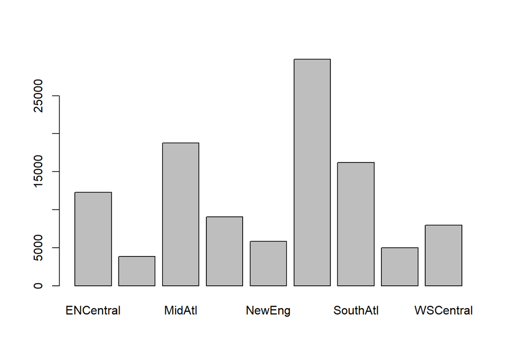

```r
total_success <- total_success %>%
  mutate(region = as.factor(region),
       category_parent = as.factor(category_parent))

plot(total_success$region)
```

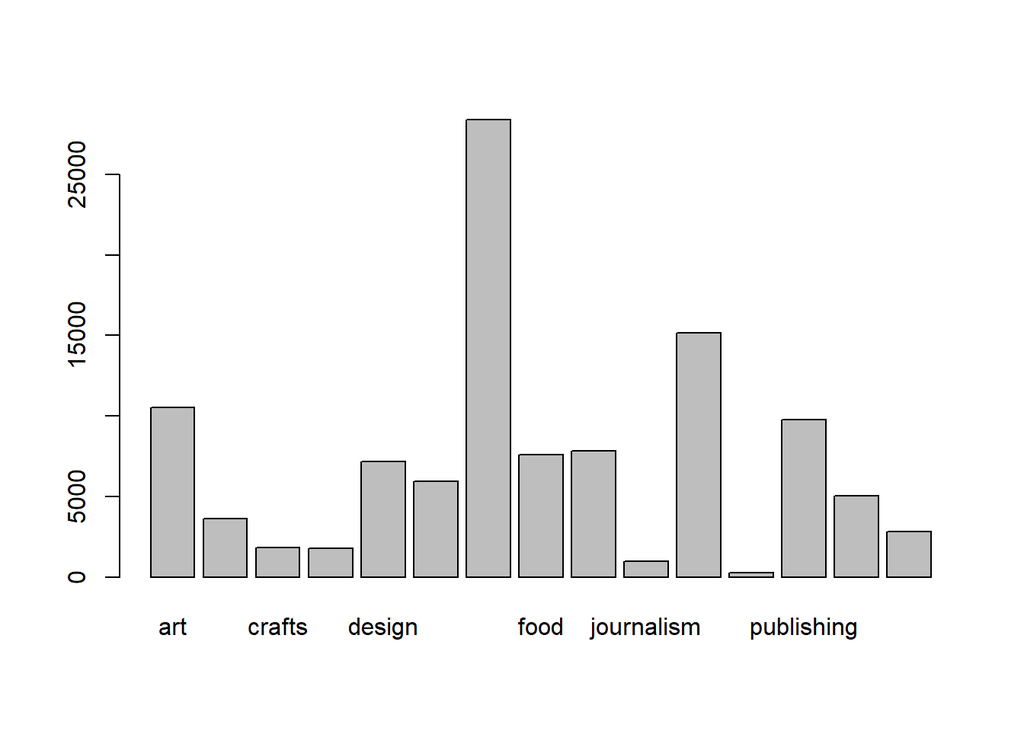

```r
plot(total_success$category_parent)
```

Converting time-series and creating time_gap = deadline - launch_date

```r
total_success <- total_success %>%
  mutate(deadline = as.Date(deadline),
         created_at = as.Date(created_at),
         launched_at = as.Date(launched_at))
```

Converting the location_slug to factors

```r
total_success <- total_success %>%
  group_by(location_slug) %>%
  mutate(location_slug_freq = n()) %>%
  ungroup() %>%
  mutate(location_slug = ifelse(location_slug_freq < 1500, 'Other Location Slug', location_slug),
         location_slug = ifelse(is.na(location_slug), 'Other Location Slug', location_slug),
         location_slug = as.factor(location_slug))

summary(total_success$location_slug)
```

```
##          atlanta-ga           austin-tx           boston-ma         brooklyn-ny
##                1658                1700                1529                2634
##          chicago-il      los-angeles-ca         new-york-ny Other Location Slug
##                3051                8690                6588               76080
##         portland-or    san-francisco-ca          seattle-wa
##                1893                2845                2060
```

**Note: We found that this is an important factor since the actual location of the project doesn’t correspond to the location of the user**

```r
total_success <- total_success %>%
  group_by(USER_LOCATION_COUNTRY) %>%
  mutate(location_country_freq = n()) %>%
  ungroup() %>%
  mutate(USER_LOCATION_COUNTRY = as.character(USER_LOCATION_COUNTRY),
         USER_LOCATION_COUNTRY = ifelse(location_country_freq < 10 | USER_LOCATION_COUNTRY == "  " | is.na(USER_LOCATION_COUNTRY), 'Other Country', USER_LOCATION_COUNTRY),
         USER_LOCATION_COUNTRY = as.factor(USER_LOCATION_COUNTRY))

summary(total_success$USER_LOCATION_COUNTRY)
```

```
##            AE            AR            AT            AU            BE
##            11            39            28           352            36
##            BG            BN            BR            CA            CH
##            13            16            36           613            48
##            CN            CO            CR            DE            DK
##            19            33            24           178            34
##            ES            FI            FR            GB            GR
##            41            22           148          1435            11
##            HK            HU            IE            IL            IN
##            10            10            32            34            20
##            IT            JP            KR            LV            MX
##            49            26            24            29            87
##            MY            NL            NO            NZ Other Country
##            17           210            45            36         20298
##            PA            PH            PR            PT            RO
##            17            13            13            14            36
##            RU            SE            SG            TH            TR
##            34            67           228            10            10
##            UA            US            ZA
##            12         84195            15
```

Using the user_location_country from the external data set , with California having nearly 24K projects

```r
total_success <- total_success %>%
  group_by(USER_LOCATION_STATE) %>%
  mutate(location_state_freq = n()) %>%
  ungroup() %>%
  mutate(USER_LOCATION_STATE = as.character(USER_LOCATION_STATE),
         USER_LOCATION_STATE = ifelse(location_state_freq < 100 | USER_LOCATION_STATE == "   " | is.na(USER_LOCATION_STATE), 'Other State', USER_LOCATION_STATE),
         USER_LOCATION_STATE = as.factor(USER_LOCATION_STATE))

summary(total_success$USER_LOCATION_STATE)
```

```
##                                AK
##                           9818                            166
## AL                             AR
##                            367                            196
## AZ                             BC
##                           1334                            132
## CA                             Central Singapore
##                          24639                            228
## CO                             CT
##                           1608                            610
## DC                             England
##                            380                           1376
## FL                             GA
##                           3587                           1695
## Guelders                       HI
##                            145                            276
## IA                             ID
##                            353                            292
## IL                             IN
##                           3175                            859
## KS                             KY
##                            369                            392
## LA                             MA
##                            574                           2324
## MD                             ME
##                           1358                            380
## MI                             MN
##                           1900                           1539
## MO                             MS
##                            886                            287
## MT                             NC
##                            238                           1594
## NE                             NH
##                            252                            305
## NJ                             NM
##                           1313                            407
## NSW                            NV
##                            124                            379
## NY                             OH
##                           9862                           1865
## OK                             ON
##                            426                            283
## OR                                                Other State
##                           1876                          12656
## PA                             RI
##                           2472                            291
## SC                             SD
##                            454                            109
## TN                             TX
##                           1030                           4716
## UT                             VA
##                           1021                           1557
## VT                             WA
##                            243                           2946
## WI                             WV
##                            939                            125
```

Cleaning the values for category_name and reducing the number of factors

```r
total_success <- total_success %>%
  group_by(category_name) %>%
  mutate(category_name_freq = n()) %>%
  ungroup() %>%
  mutate(category_name = ifelse(category_name_freq < 3000, 'Other Category', category_name),
         category_name = ifelse(is.na(category_name), 'Other Category', category_name),
         category_name = as.factor(category_name))

summary(total_success$category_name)
```

```
##         Comics    Documentary        Fashion    Film  Video           Food
##           3094           7198           4560           5465           5714
##          Music Narrative Film Other Category Product Design         Shorts
##           4884           3174          55499           5241           7448
## Tabletop Games    Video Games
##           3391           3060
```

```r
total_success <- total_success %>%
  mutate(afinn_overall = afinn_pos - afinn_neg,
         afinn_overall = ifelse(is.na(afinn_overall), 0, afinn_overall))
```

```r
total_success <- total_success %>%
  mutate(success = ifelse(success == "YES", 1, 0))
```

```r
total_success <- total_success %>%
  mutate(proj_duration = as.numeric(launched_at - created_at))
```

Converted the project launch date to day of the week and found that most projects were launched on a **Tuesday**

```r
total_success <- total_success %>%
  mutate(day_of_week = as.factor(as.character(format(launched_at, format="%A"))))

summary(total_success$day_of_week)
```

```
##    Friday    Monday  Saturday    Sunday  Thursday   Tuesday Wednesday
##     17785     17736      8656      5299     18322     21225     19705
```

```r
check <- table(total_success$success, total_success$day_of_week)
prop.table(check, 2)
```

```
##
##        Friday    Monday  Saturday    Sunday  Thursday   Tuesday Wednesday
##   0 0.6018762 0.5811637 0.6162537 0.5914389 0.5865396 0.5792145 0.5806378
##   1 0.3981238 0.4188363 0.3837463 0.4085611 0.4134604 0.4207855 0.4193622
```

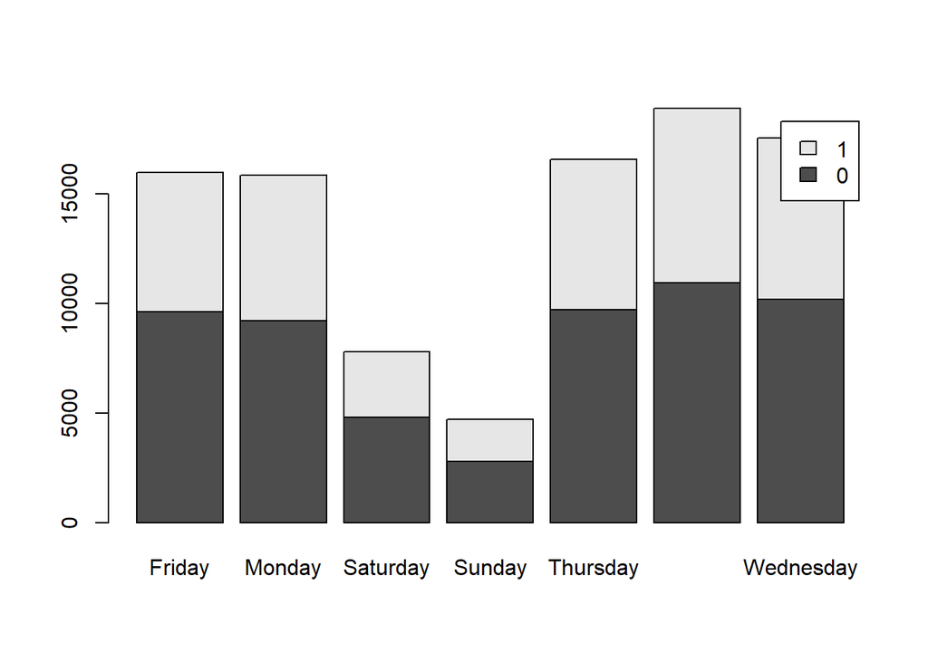

```r
barplot(check, legend.text = rownames(check))
```

```r
total_success <- total_success %>%
  mutate(launched_at = as.numeric(launched_at))
```

```r
total_success <- total_success %>%
  mutate(reward_descriptions = ifelse(is.na(reward_descriptions), "None", reward_descriptions),
         blurb = ifelse(is.na(blurb), "None", blurb),
         name = ifelse(is.na(name), "None", name),
         captions = ifelse(is.na(captions), "None", captions),
         tag_names = ifelse(is.na(tag_names), "None", tag_names))
```

```r
total_success <- total_success %>%
  mutate(extra_female_creators = female_creator - male_creator)
```

```r
total_success <- total_success %>%
  mutate(contains_youtube = as.factor(contains_youtube))

summary(total_success$contains_youtube)
```

```
##      0      1
## 100898   7830
```

```r
check <- table(total_success$success, total_success$contains_youtube)
prop.table(check, 2)
```

```
##
##             0         1
##   0 0.5835060 0.6486562
##   1 0.4164940 0.3513438
```

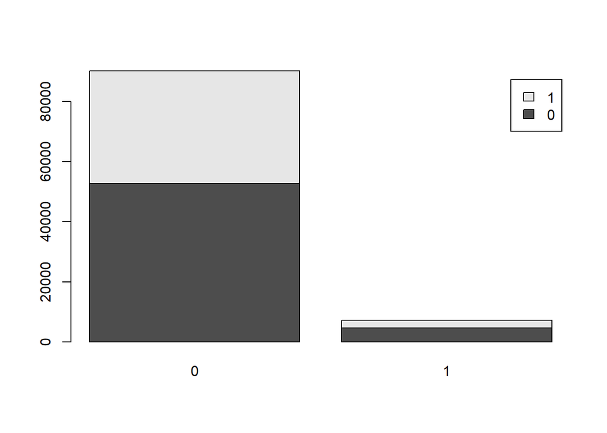

```r
barplot(check, legend.text = rownames(check))
```

```r
total_success <- total_success %>%
  mutate(time_gap = as.numeric(deadline - launched_at))
```

Understanding Goal, we see the variable goal has values centered around 0 -5000 and huge outliers and thus without categorizing we’d like to see the impact of goal on the success variable and interact with few other terms like category etc.

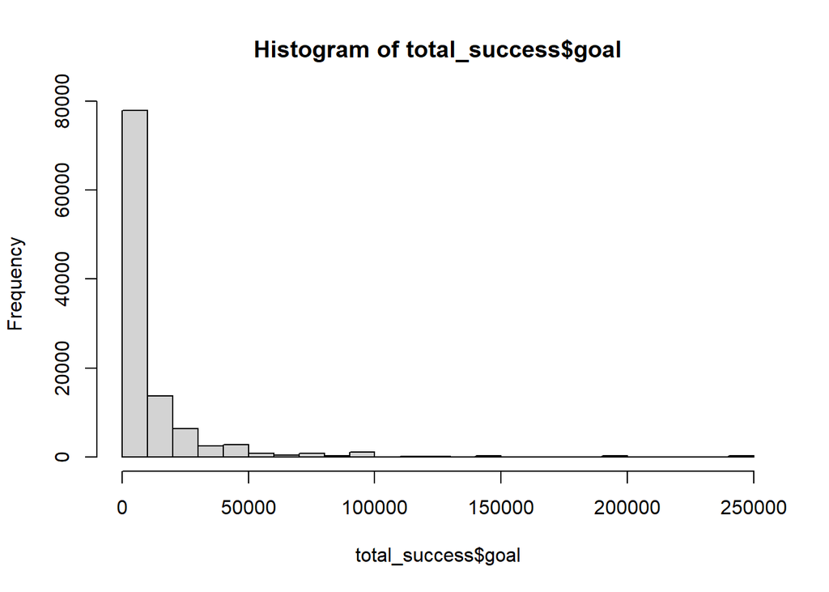

```r
hist(total_success$goal)
```

```r
summary(total_success)
```

```
##     success           goal              id                name
##  Min.   :0.000   Min.   :   100   Min.   :5.971e+03   Length:108728
##  1st Qu.:0.000   1st Qu.:  2000   1st Qu.:5.372e+08   Class :character
##  Median :0.000   Median :  5000   Median :1.076e+09   Mode  :character
##  Mean   :0.412   Mean   : 13788   Mean   :1.076e+09
##  3rd Qu.:1.000   3rd Qu.: 14000   3rd Qu.:1.613e+09
##  Max.   :1.000   Max.   :250000   Max.   :2.147e+09
##  NA's   :11308
##     blurb             captions          tag_names
##  Length:108728      Length:108728      Length:108728
##  Class :character   Class :character   Class :character
##  Mode  :character   Mode  :character   Mode  :character
##
##
##
##
##    USER_LOCATION_COUNTRY                     USER_LOCATION_STATE
##  US           :84195     CA                            :24639
##  Other Country:20298     Other State                   :12656
##  GB           : 1435     NY                            : 9862
##  CA           :  613                                   : 9818
##  AU           :  352     TX                            : 4716
##  SG           :  228     FL                            : 3587
##  (Other)      : 1607     (Other)                       :43450
##        region          category_parent    num_words
##  Pacific  :29798   film & video:28407   Min.   :    0.0
##  MidAtl   :18774   music       :15163   1st Qu.:  217.0
##  SouthAtl :16183   art         :10526   Median :  389.0
##  ENCentral:12260   publishing  : 9789   Mean   :  544.3
##  Mountain : 9064   games       : 7841   3rd Qu.:  694.0
##  WSCentral: 7971   food        : 7605   Max.   :14270.0
##  (Other)  :14678   (Other)     :29397
##         category_name   avg_wordlengths     deadline           launched_at
##  Other Category:55499   Min.   : 0.000   Min.   :2009-05-15   Min.   :14355
##  Shorts        : 7448   1st Qu.: 4.396   1st Qu.:2012-04-01   1st Qu.:15394
##  Documentary   : 7198   Median : 4.609   Median :2013-03-29   Median :15761
##  Food          : 5714   Mean   : 4.625   Mean   :2013-02-15   Mean   :15717
##  Film  Video   : 5465   3rd Qu.: 4.836   3rd Qu.:2014-03-26   3rd Qu.:16122
##  Product Design: 5241   Max.   :68.000   Max.   :2014-12-02   Max.   :16400
##  (Other)       :22163
```

[output cut: 73 more lines]

```
##  Min.   :    1         Min.   :    1       Min.   :   2       Min.   :-57.000
##  1st Qu.:84195         1st Qu.: 1608       1st Qu.:1273       1st Qu.:  3.000
##  Median :84195         Median : 9818       Median :2859       Median :  7.000
##  Mean   :67091         Mean   : 9300       Mean   :3293       Mean   :  8.859
##  3rd Qu.:84195         3rd Qu.:10333       3rd Qu.:5241       3rd Qu.: 13.000
##  Max.   :84195         Max.   :24639       Max.   :7448       Max.   : 91.000
##
##  proj_duration        day_of_week    extra_female_creators    time_gap
##  Min.   :   0.00   Friday   :17785   Min.   :-8.0000       Min.   : 1.00
##  1st Qu.:   4.00   Monday   :17736   1st Qu.:-1.0000       1st Qu.:30.00
##  Median :  12.00   Saturday : 8656   Median : 0.0000       Median :30.00
##  Mean   :  38.49   Sunday   : 5299   Mean   :-0.1306       Mean   :34.95
##  3rd Qu.:  35.00   Thursday :18322   3rd Qu.: 0.0000       3rd Qu.:40.00
##  Max.   :1655.00   Tuesday  :21225   Max.   : 7.0000       Max.   :92.00
##                    Wednesday:19705
```

## Formula for model building

```r
formula <- success ~ USER_LOCATION_STATE+USER_LOCATION_COUNTRY+goal+region+category_parent+num_words+grade_level+minage_creator+avg_wordlengths+time_gap+location_slug+category_name+afinn_overall+contains_youtube+avgsentencelength+numfaces_creator+sentence_counter+ADV+NOUN+ADP+PRT+DET+VERB+CONJ+num_rewards+min_reward+sd_reward+max_reward+extra_female_creators+numfaces_project+minage_project+smiling_creator+proj_duration:goal+category_parent:goal+maxage_creator:goal+proj_duration:numfaces_creator+num_words:proj_duration+contains_youtube:goal+goal:max_reward+grade_level:maxage_creator+afinn_overall:category_parent+grade_level:category_parent+day_of_week
```

## Adding Original to allow split for labeled and use_data

```r
labeled_data <- total_success %>%
  filter(original_TR == 1)

use_data <- total_success %>%
  filter(original_TR == 0)

original_TR_indices <- which(as.logical(total_success$original_TR))
```

## Text featuriztion of Blurb , Captions , Name , Reward desc ,Tag_names

Unstructured text was pruned with the not useful stopwords, stemming was done , punctuations were removed, numbers were removed . Having uni- and bi- grams and term_count_min = 20, doc_count_min = 10.

```r
# Reward Description Column

cleaning_tokenizer <- function(v) {
  v %>%
    removeNumbers %>% #remove all numbers
    removePunctuation %>% #remove all punctuation
    removeWords(stopwords(kind="en")) %>% #remove stopwords
    stemDocument %>%
    word_tokenizer
}

prep_fun = tolower
tok_fun = cleaning_tokenizer



it_reward = itoken(total_success$reward_descriptions,
                   preprocessor = prep_fun,
                   tokenizer = tok_fun,
                   ids = total_success$id,
                   progressbar = FALSE)

stop_words_reward = c("None", "will", "copi", "plus", "receiv", "get", "one", "includ", "ship", "special", "also", "print", "will_receiv", "download", "edit", "x", "choic", "list", "us", "well", "can", "add", "two", "limit", "youll", "limit_edit")
vocab_reward = create_vocabulary(it_reward, ngram = c(1L, 2L), stopwords = stop_words_reward)

vocab_reward <- prune_vocabulary(vocab_reward, term_count_min = 20, doc_count_min = 10)

vectorizer_reward = vocab_vectorizer(vocab_reward)

dtm_reward = create_dtm(it_reward, vectorizer_reward)

# Name column

it_name = itoken(total_success$name,
                 preprocessor = prep_fun,
                 tokenizer = tok_fun,
                 ids = total_success$id,
                 progressbar = FALSE)

stop_words_name = c("None", "new", "short", "help", "make", "one", "live", "collect", "get")

vocab_name = create_vocabulary(it_name, ngram = c(1L, 2L), stopwords = stop_words_name)

vocab_name <- prune_vocabulary(vocab_name, term_count_min = 20, doc_count_min = 10)

vectorizer_name = vocab_vectorizer(vocab_name)

dtm_name = create_dtm(it_name, vectorizer_name)

# Blurb column

it_blurb = itoken(total_success$blurb,
                  preprocessor = prep_fun,
                  tokenizer = tok_fun,
                  ids = total_success$id,
                  progressbar = FALSE)
stop_words_blurb <- c("None", "help", "new", "one", "short", "two", "like", "start", "build", "come", "look", "go", "made", "will", "make", "need", "creat", "us", "get", "can", "live", "want", "bring", "work", "take", "use", "play")
vocab_blurb = create_vocabulary(it_blurb, ngram = c(1L, 2L), stopwords = stop_words_blurb)

vocab_blurb <- prune_vocabulary(vocab_blurb, term_count_min = 20, doc_count_min = 10)

vectorizer_blurb = vocab_vectorizer(vocab_blurb)

dtm_blurb = create_dtm(it_blurb, vectorizer_blurb)

# Captions column

it_captions = itoken(total_success$captions,
                     preprocessor = prep_fun,
                     tokenizer = tok_fun,
                     ids = total_success$id,
                     progressbar = FALSE)

stop_words_captions <- c("none", "close", "front", "white", "black", "red", "blue", "larg", "green", "yellow", "next")
vocab_captions = create_vocabulary(it_captions, ngram = c(1L, 2L))

vocab_captions <- prune_vocabulary(vocab_captions, term_count_min = 20, doc_count_min = 10)

vectorizer_captions = vocab_vectorizer(vocab_captions)

dtm_captions = create_dtm(it_captions, vectorizer_captions)

# Tag names column

it_tag_names = itoken(total_success$tag_names,
                      preprocessor = prep_fun,
                      tokenizer = tok_fun,
                      ids = total_success$id,
                      progressbar = FALSE)

stop_words_tag_names <- c("none", "white", "fast", "black")
vocab_tag_names = create_vocabulary(it_tag_names, ngram = c(1L, 2L))

vocab_tag_names <- prune_vocabulary(vocab_tag_names, term_count_min = 20, doc_count_min = 10)

vectorizer_tag_names = vocab_vectorizer(vocab_tag_names)

dtm_tag_names = create_dtm(it_tag_names, vectorizer_tag_names)
```

## Converting the data to matrix for labeled and use_data

```r
labeled_data_matrix <- model.matrix(formula, model.frame(~., labeled_data, na.action=na.pass))

labeled_data_matrix <- cbind(labeled_data_matrix, dtm_reward[original_TR_indices,], dtm_name[original_TR_indices,], dtm_blurb[original_TR_indices,], dtm_captions[original_TR_indices,])

use_data_matrix <- model.matrix(formula,model.frame(~ ., use_data, na.action=na.pass))

use_data_matrix <- cbind(use_data_matrix, dtm_reward[-original_TR_indices,], dtm_name[-original_TR_indices,], dtm_blurb[-original_TR_indices,], dtm_captions[-original_TR_indices,])
```

## Splitting and validation selection

Simple split 70-30 was preferred since the choice of modelling was going to ensemble which would include bagging and boosting and cross-validation would be implemented in other models.

```r
set.seed(1)
training_indices <- sample(nrow(labeled_data_matrix), .7*nrow(labeled_data_matrix))
tr_x <- labeled_data_matrix[training_indices,]
va_x <- labeled_data_matrix[-training_indices,]

tr_y <- labeled_data[training_indices,]$success
va_y <- labeled_data[-training_indices,]$success
```

## Best Model : XGBoost

XGBoost with the hyper parameters max.depth = 4, eta = 0.2, nrounds = 900 gave the highest accuracy and hence was selected .

```r
knitr::opts_chunk$set(echo = TRUE)
bst <- xgboost(data = tr_x, label = tr_y, max.depth = 4, eta = 0.2, nrounds = 900,  objective = "binary:logistic")
```

```
## [11:57:29] WARNING: amalgamation/../src/learner.cc:1115: Starting in XGBoost 1.3.0, the default evaluation metric used with the objective 'binary:logistic' was changed from 'error' to 'logloss'. Explicitly set eval_metric if you'd like to restore the old behavior.
```

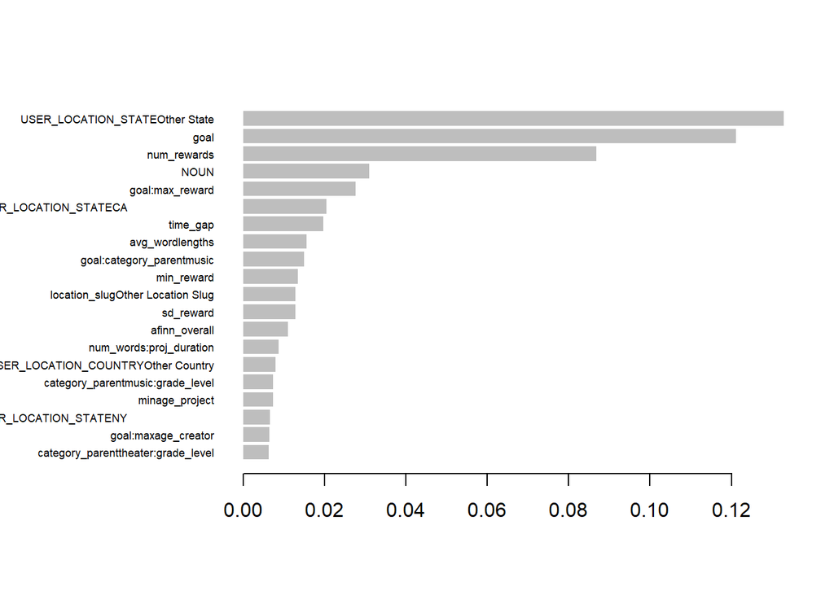

```r
# Variable importance chart
importance_matrix = xgb.importance(colnames(labeled_data_matrix), model = bst)
imp.df <- data.frame(importance_matrix)
xgb.plot.importance(importance_matrix[1:20,])
```

```r
bst_pred <- predict(bst, va_x, type='response')
bst_classifications <- ifelse(bst_pred > 0.5, 1, 0)
bst_acc <- mean(ifelse(bst_classifications == va_y, 1, 0))

bst_acc
```

```
## [1] 0.7846438
```

```r
# Predict for use data
bst_pred_use <- predict(bst, use_data_matrix, type='response')
preds_class <- ifelse(bst_pred_use>.5,"YES","NO")

#output your predictions
write.table(preds_class, "success_group26.csv", row.names = FALSE)
```

## Other Models : Boosting

```r
set.seed(1)
training_indices_boost <- sample(nrow(labeled_data), .7*nrow(labeled_data))
tr <- labeled_data[training_indices_boost,]
va <- labeled_data[-training_indices_boost,]

tr_boost <- labeled_data[training_indices_boost,]$success
va_boost <- labeled_data[-training_indices_boost,]$success

boost.mod <- gbm(formula,data=tr,
                 distribution="bernoulli",
                 n.trees=5000,
                 interaction.depth=3)
```

```r
boost_preds <- predict(boost.mod,newdata=va,type='response',n.trees=5000)

boost_class <- ifelse(boost_preds>.5,1,0)
boost_acc <- mean(ifelse(boost_class==va_boost,1,0))
boost_acc
```

```
## [1] 0.7745843
```

## Ridge and Lasso with 5-fold cross validation

```r
# grid for ridge and lasso
grid <- 10^seq(20,-20,length=100)

#glmnet automatically does cross-validation for you, you just need to specify k.
k<-5

model <- success ~ USER_LOCATION_COUNTRY+goal+region+category_parent+num_words+grade_level+minage_creator+avg_wordlengths+time_gap+location_slug+category_name+afinn_overall+contains_youtube+avgsentencelength+numfaces_creator+sentence_counter+ADV+NOUN+ADP+PRT+DET+VERB+CONJ+extra_female_creators+numfaces_project+minage_project+smiling_creator+proj_duration:goal+category_parent:goal+maxage_creator:goal+proj_duration:numfaces_creator+num_words:proj_duration+contains_youtube:goal+grade_level:maxage_creator+afinn_overall:category_parent+grade_level:category_parent+day_of_week

labeled_data_matrix_log <- model.matrix(model, model.frame(~., labeled_data, na.action=na.pass))

use_data_matrix_log <- model.matrix(model,model.frame(~ ., use_data, na.action=na.pass))

set.seed(1)
training_indices <- sample(nrow(labeled_data_matrix_log), .7*nrow(labeled_data_matrix_log))
tr_x_log <- labeled_data_matrix_log[training_indices,]
va_x_log <- labeled_data_matrix_log[-training_indices,]

tr_y_log <- labeled_data[training_indices,]$success
va_y_log <- labeled_data[-training_indices,]$success
```

```r
#family="binomial" yields logistic regression; family="gaussian" yields linear regression
#alpha = 1 yields the lasso penalty, and alpha= 0 the ridge penalty
cv.out.lasso <- cv.glmnet(tr_x_log , tr_y_log, family="binomial", alpha=1, lambda=grid, nfolds=k)
```

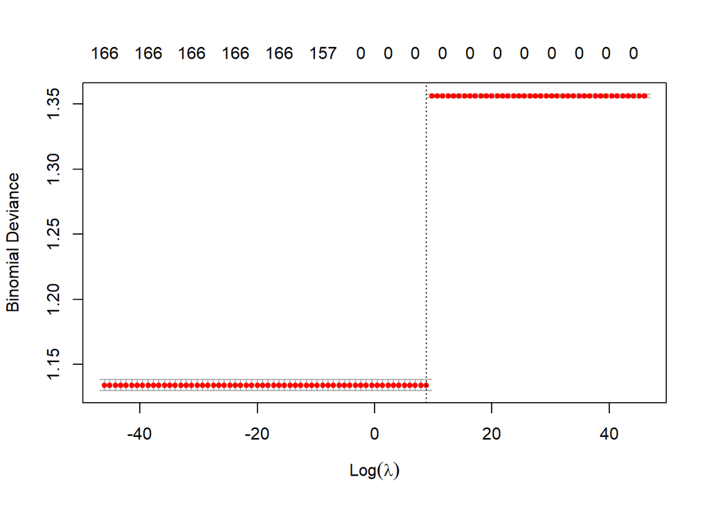

```r
plot(cv.out.lasso)
```

```r
bestlam.lasso <- cv.out.lasso$lambda.min
bestlam.lasso
```

```
## [1] 6892.612
```

```r
pred.lasso <- predict(cv.out.lasso, s=bestlam.lasso, newx = va_x_log)
valid_classifications.lasso <- ifelse(pred.lasso >= 0.5, 1, 0)
valid_acc.lasso <- mean(ifelse(valid_classifications.lasso == va_y, 1, 0))

valid_acc.lasso
```

```
## [1] 0.6851434
```

```r
cv.out.ridge <- cv.glmnet(tr_x_log , tr_y_log, family="binomial", alpha=0, lambda=grid, nfolds=k)
```

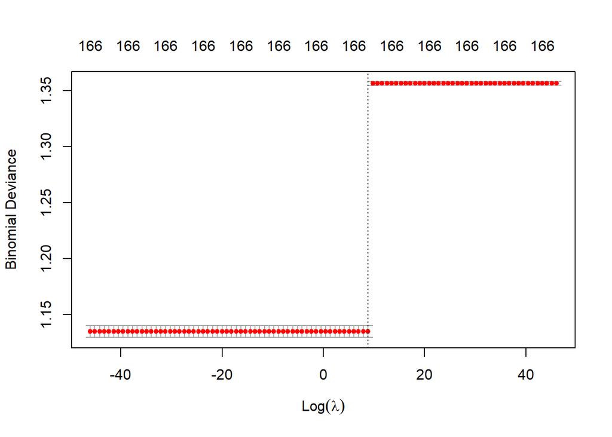

```r
plot(cv.out.ridge)
```

```r
bestlam.ridge <- cv.out.ridge$lambda.min
bestlam.ridge
```

```
## [1] 6892.612
```

```r
pred.ridge <- predict(cv.out.ridge, s=bestlam.ridge, newx = va_x_log)
valid_classifications.ridge <- ifelse(pred.ridge >= 0.5, 1, 0)
valid_acc.ridge <- mean(ifelse(valid_classifications.ridge == va_y, 1, 0))

valid_acc.ridge
```

```
## [1] 0.685246
```

## Logistic Regression

```r
# log
log_model <- glm(formula, data = tr, family = "binomial")
prediction_log <- predict(log_model, newdata = va , type = "response")
prediction_log <- ifelse(is.na(prediction_log),0,prediction_log)
classification_log <- ifelse(prediction_log > .5, 1 , 0)

#Evaluation, assessing if the predictions match the actual values or not, then calculate the accuracy
correct_log <- ifelse(classification_log == va_boost, 1, 0)
accuracy_log = sum(correct_log)/length(correct_log)

accuracy_log
```

```
## [1] 0.7305824
```

## KNN - K=5

```r
knn.pred=knn(tr_x_log, #the training instances' features
             va_x_log, #the new instances we want to make predictions for
             tr_y_log, #the y values in the training data
             k=5, #choose k
             prob = TRUE) #get probabilities as well
```

```r
knn.probs <- attr(knn.pred, "prob")
knn.prob_of_positive <- ifelse(knn.pred == 1, knn.probs, 1-knn.probs)
knn_classifications<- ifelse(knn.prob_of_positive > 0.5, 1, 0)
knn_acc <- mean(ifelse(knn_classifications == va_boost, 1, 0))
knn_acc
```

```
## [1] 0.6179087
```

## Fitting Curves K-NN

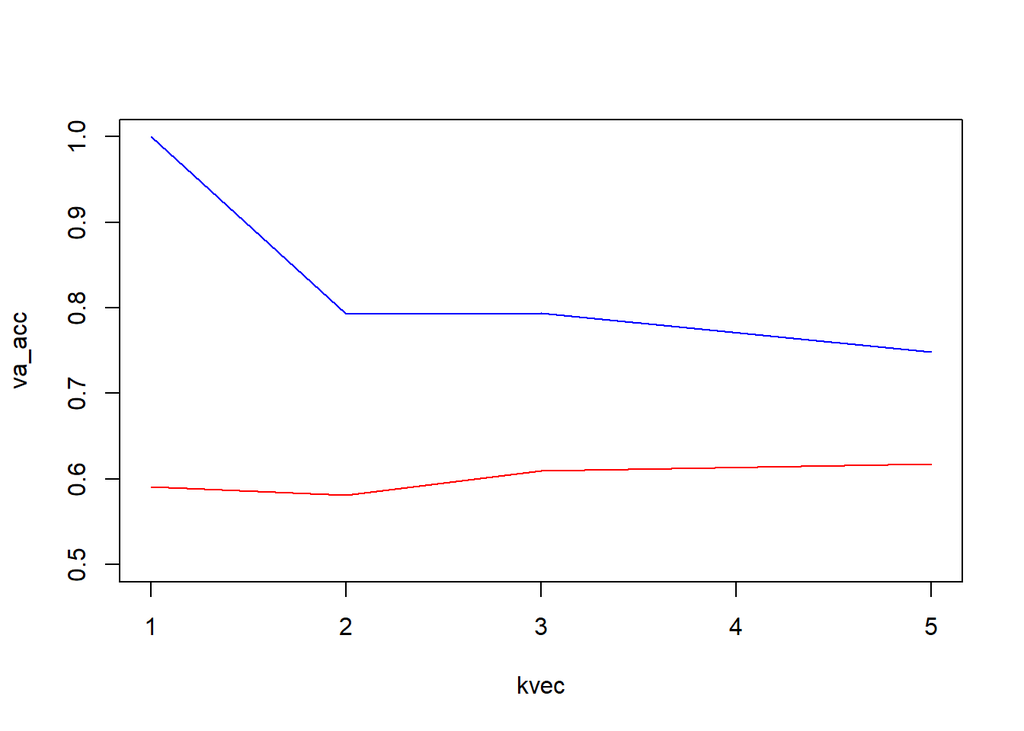

```r
kvec <- c(1,2,3,5) #you can change this if you want

#initialize storage
va_acc <- rep(0, length(kvec))
tr_acc <- rep(0, length(kvec))

accuracy <- function(classifications, actuals){
  correct_classifications <- ifelse(classifications == actuals, 1, 0)
  acc <- sum(correct_classifications)/length(classifications)
  return(acc)
}

#for loop
for(i in 1:length(kvec)){
  k <- kvec[i] #get the ith k in kvec

  #compute predictions using train.X as the potential neighbors
  #new points to be classified are first validation, then training points
  va_preds <- knn(tr_x_log, va_x_log, tr_y_log, k = k)
  tr_preds <- knn(tr_x_log, tr_x_log, tr_y_log, k = k)

  #compute the accuracy for each set of predictions
  va_accuracy <- accuracy(va_preds, va_y_log)
  tr_accuracy <- accuracy(tr_preds, tr_y_log)

  #store in the appropriate place
  va_acc[i] <- va_accuracy
  tr_acc[i] <- tr_accuracy

}

#make the plot
plot(kvec, va_acc, col = 'red', type = 'l', ylim = c(0.5,1))
lines(kvec, tr_acc, col = 'blue')
```

## Fitting curves Ridge & Lasso

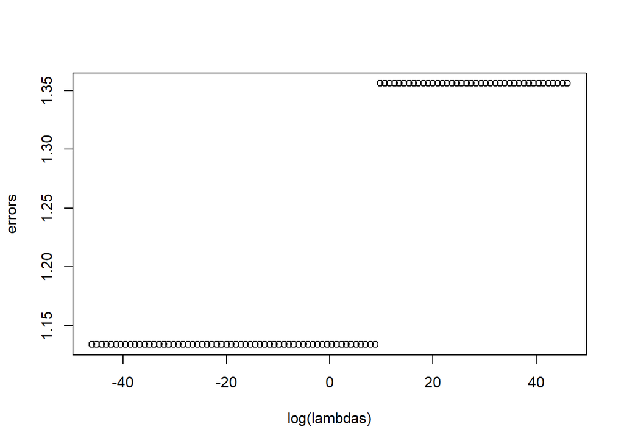

```r
##Lasso
lambdas <- cv.out.lasso$lambda
errors <- cv.out.lasso$cvm

#with this particular set of lambdas, you can see the curve easier if you plot them on a log-log scale
plot(log(lambdas), errors)
```

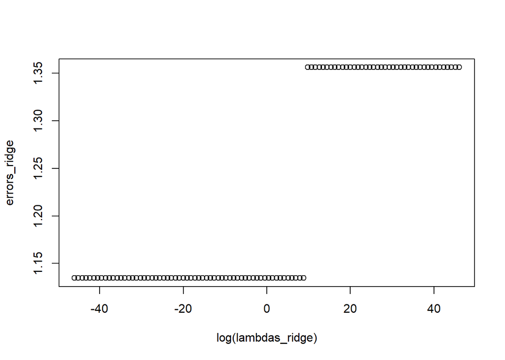

```r
lambdas_ridge <- cv.out.ridge$lambda
errors_ridge <- cv.out.ridge$cvm


#with this particular set of lambdas, you can see the curve easier if you plot them on a log-log scale
plot(log(lambdas_ridge), errors_ridge)
```

## Fitting Curve XgBoost

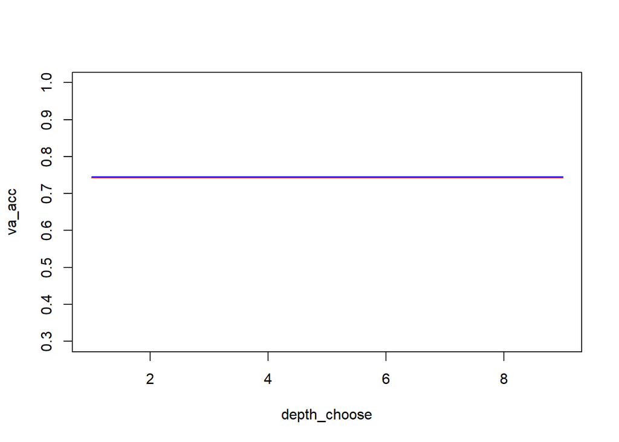

```r
#three hyperparameters can possibly really change predictive performance of xgboost (although maybe not)
depth_choose <- c(1, 2 , 4 , 5 , 7 , 9 )


va_acc <- rep(0, length(depth_choose))
tr_acc <- rep(0, length(depth_choose))



for(j in c(1:length(depth_choose)))
  {
        thisnrounds <- depth_choose[j]

        inner_bst <- xgboost(data = tr_x,  label = tr_y, max.depth = depth_choose , eta = 0.2, nrounds = 100,  objective = "binary:logistic", verbosity = 0, verbose = 0)

        inner_bst_pred_valid <- predict(inner_bst, va_x, type= "response")
        inner_bst_classifications_valid <- ifelse(inner_bst_pred_valid > 0.5, 1, 0)
        inner_bst_acc_valid <- mean(ifelse(inner_bst_classifications_valid == va_y, 1, 0))

        inner_bst_pred_train <- predict(inner_bst, tr_x, type= "response")
        inner_bst_classifications_train <- ifelse(inner_bst_pred_train > 0.5, 1, 0)
        inner_bst_acc_train <- mean(ifelse(inner_bst_classifications_train == tr_y, 1, 0))

          va_acc[j] <- inner_bst_acc_valid
          tr_acc[j] <- inner_bst_acc_train
  }


#make the plot
plot(depth_choose, va_acc, col = 'red', type = 'l', ylim = c(0.3,1))
lines(depth_choose, tr_acc, col = 'blue')
```

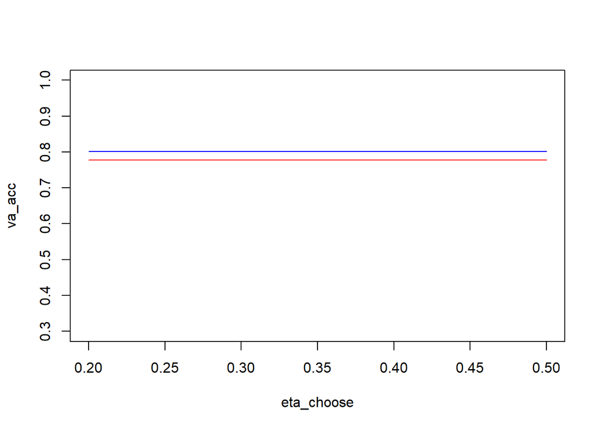

```r
#three hyperparameters can possibly really change predictive performance of xgboost (although maybe not)
eta_choose <- c(0.2,0.3,0.5 )


va_acc <- rep(0, length(eta_choose))
tr_acc <- rep(0, length(eta_choose))



for(j in c(1:length(eta_choose)))
  {
        thisnrounds <- eta_choose[j]

        inner_bst <- xgboost(data = tr_x,  label = tr_y, max.depth = 4 , eta = eta_choose, nrounds = 100,  objective = "binary:logistic", verbosity = 0, verbose = 0)

        inner_bst_pred_valid <- predict(inner_bst, va_x, type= "response")
        inner_bst_classifications_valid <- ifelse(inner_bst_pred_valid > 0.5, 1, 0)
        inner_bst_acc_valid <- mean(ifelse(inner_bst_classifications_valid == va_y, 1, 0))

        inner_bst_pred_train <- predict(inner_bst, tr_x, type= "response")
        inner_bst_classifications_train <- ifelse(inner_bst_pred_train > 0.5, 1, 0)
        inner_bst_acc_train <- mean(ifelse(inner_bst_classifications_train == tr_y, 1, 0))

          va_acc[j] <- inner_bst_acc_valid
          tr_acc[j] <- inner_bst_acc_train
  }


#make the plot
plot(eta_choose, va_acc, col = 'red', type = 'l', ylim = c(0.3,1))
lines(eta_choose, tr_acc, col = 'blue')
```

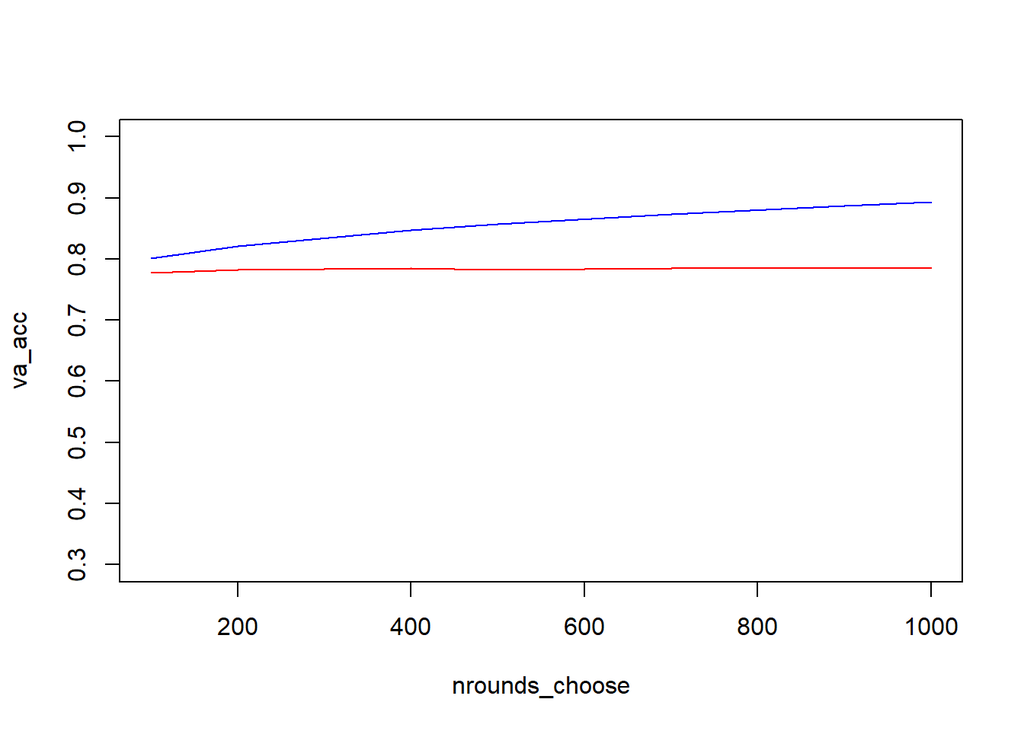

```r
#three hyperparameters can possibly really change predictive performance of xgboost (although maybe not)
nrounds_choose <- c(100, 200 , 400 , 500 , 700 , 900 , 1000)


va_acc <- rep(0, length(nrounds_choose))
tr_acc <- rep(0, length(nrounds_choose))



for(j in c(1:length(nrounds_choose)))
  {
        thisnrounds <- nrounds_choose[j]

        inner_bst <- xgboost(data = tr_x,  label = tr_y, max.depth = 4, eta = 0.2, nrounds = thisnrounds,  objective = "binary:logistic", verbosity = 0, verbose = 0)

        inner_bst_pred_valid <- predict(inner_bst, va_x, type= "response")
        inner_bst_classifications_valid <- ifelse(inner_bst_pred_valid > 0.5, 1, 0)
        inner_bst_acc_valid <- mean(ifelse(inner_bst_classifications_valid == va_y, 1, 0))

        inner_bst_pred_train <- predict(inner_bst, tr_x, type= "response")
        inner_bst_classifications_train <- ifelse(inner_bst_pred_train > 0.5, 1, 0)
        inner_bst_acc_train <- mean(ifelse(inner_bst_classifications_train == tr_y, 1, 0))

          va_acc[j] <- inner_bst_acc_valid
          tr_acc[j] <- inner_bst_acc_train
  }


#make the plot
plot(nrounds_choose, va_acc, col = 'red', type = 'l', ylim = c(0.3,1))
lines(nrounds_choose, tr_acc, col = 'blue')
```

## Lift Curve , ROC for all models & AUC for XgBoost

```r
bst_auc <- prediction(bst_pred, va_y)
performance(bst_auc, measure = "auc")@y.values[[1]]
```

```
## [1] 0.8679449
```

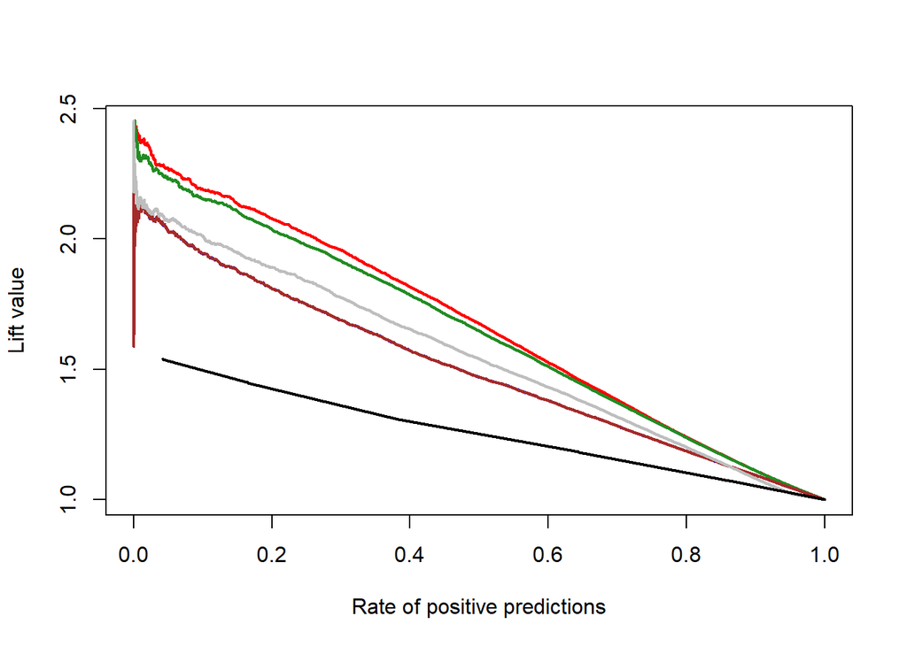

```r
boost_auc <- prediction(boost_preds, va_boost)
ridge_auc <- prediction(pred.ridge, va_y_log)
lasso_auc <- prediction(pred.lasso, va_y_log)
log_auc <- prediction(prediction_log, va_boost)
knn_auc <- prediction(knn.prob_of_positive, va_y_log)

lift_bst <- performance(bst_auc, "lift", "rpp")
lift_lasso <- performance(lasso_auc, "lift", "rpp")
lift_ridge <- performance(ridge_auc, "lift", 'rpp')
lift_log <- performance(log_auc, "lift", 'rpp')
lift_boost <- performance(boost_auc, "lift", 'rpp')
lift_knn <- performance(knn_auc, "lift", 'rpp')

roc_bst <- performance(bst_auc, "tpr", "fpr")
roc_lasso <- performance(lasso_auc, "tpr", "fpr")
roc_ridge <- performance(ridge_auc, "tpr", "fpr")
roc_log <- performance(log_auc,"tpr", "fpr")
roc_boost <- performance(boost_auc, "tpr", "fpr")
roc_knn <- performance(knn_auc, "tpr", "fpr")


plot(lift_bst, col = "red", lwd = 2)
plot(lift_lasso, add = T, col  = "blue", lwd = 2)
plot(lift_boost, add = T, col = "forestgreen", lwd = 2)
plot(lift_ridge, add = T, col = "brown", lwd = 2)
plot(lift_log, add = T, col = "gray", lwd = 2)
plot(lift_knn, add = T, col = "black", lwd = 2)
```

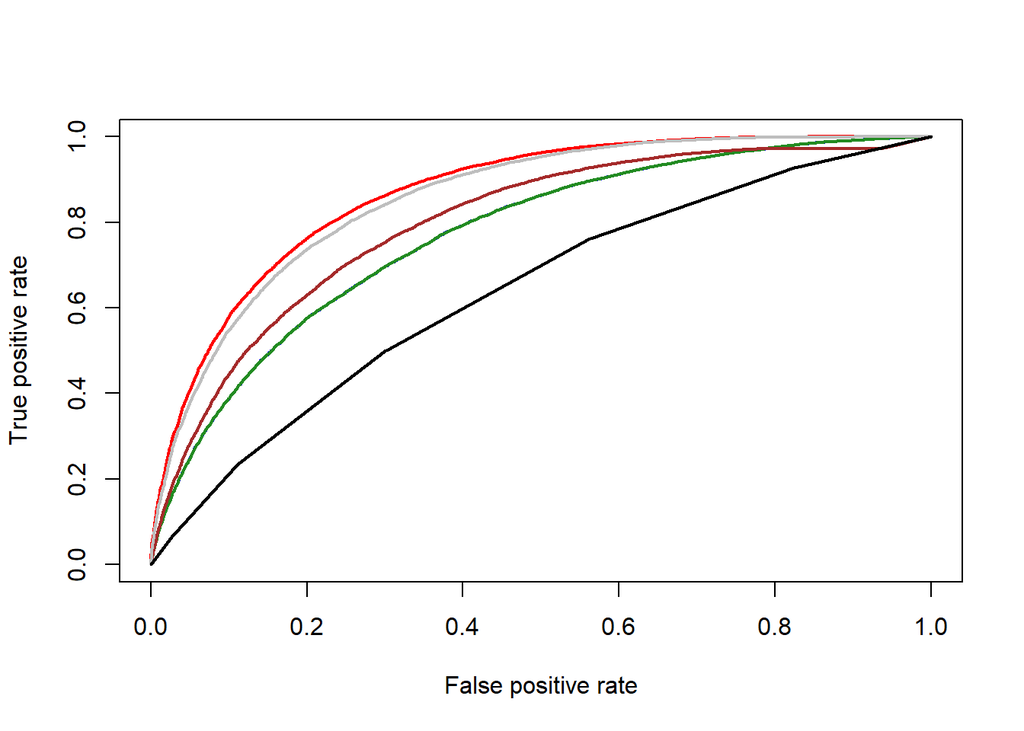

```r
plot(roc_bst, col = "red", lwd = 2)
plot(roc_lasso, add = T, col  = "blue", lwd = 2)
plot(roc_ridge, add = T, col = "forestgreen", lwd = 2)
plot(roc_log, add = T, col = "brown", lwd = 2)
plot(roc_boost, add = T, col = "gray", lwd = 2)
plot(roc_knn, add = T, col = "black", lwd = 2)
```